```python
#Primero hacemos la importación de las librerías necesarias para la exploración y graficación de los datos.
import pandas as pd
import seaborn as sns
import matplotlib.pyplot as plt
import matplotlib as mpl
import numpy as np
```

```python
#Importamos el archivo y mostramos el head.
df = pd.read_csv("bicimad_full.csv")
df.head()
```

|  | timestamp | public_station_id | station_id | name | address | longitude | latitude | total_bases | active_bases | available_bikes | free_bases | status | real_status |
| --- | --- | --- | --- | --- | --- | --- | --- | --- | --- | --- | --- | --- | --- |
| 0 | 2025-04-08 09:00:01 | 5 | 1409 | Fuencarral | Calle Fuencarral n. 106 | -3.702135 | 40.428521 | 27 | 27 | 17 | 10 | 1 | active |
| 1 | 2025-04-08 09:00:01 | 8 | 1412 | Metro Alonso Martinez | Plaza de Alonso Martinez n. 6 | -3.695440 | 40.427868 | 24 | 24 | 7 | 17 | 1 | active |
| 2 | 2025-04-08 09:00:01 | 10 | 1414 | Marques de la Ensenada | Calle Marques de la Ensenada (junto a edif, Ce... | -3.692104 | 40.425403 | 23 | 23 | 3 | 20 | 1 | active |
| 3 | 2025-04-08 09:00:01 | 11 | 1415 | Plaza del Dos de Mayo | Calle San Andres n. 18 - 20 | -3.703600 | 40.427000 | 23 | 23 | 1 | 22 | 1 | active |
| 4 | 2025-04-08 09:00:01 | 609 | 2286 | Metro Ronda de la Comunicacion | Ronda de la Comunicacion, s/n | -3.662689 | 40.515720 | 23 | 23 | 1 | 22 | 1 | active |

# **ANALISIS EXPLORATORIO DE LOS DATOS**

## **Mapa Operativo de BiciMAD basado en la última recolección realizada**

```python
import folium
from folium.plugins import MarkerCluster
from datetime import datetime
from branca.element import Template, MacroElement

# Configuración general para un estilo más profesional
plt.style.use('seaborn-v0_8-whitegrid')

# Configuración global de matplotlib para una mejor apariencia
mpl.rcParams['font.family'] = 'sans-serif'
mpl.rcParams['font.sans-serif'] = ['Arial', 'Helvetica', 'DejaVu Sans']
mpl.rcParams['axes.edgecolor'] = '#333333'
mpl.rcParams['axes.linewidth'] = 1.2
mpl.rcParams['xtick.color'] = '#333333'
mpl.rcParams['ytick.color'] = '#333333'

# Extraer el último timestamp
timestamps = df["timestamp"].unique()
last_timestamp = timestamps[-1]

# Filtrar el dataframe para obtener solo los datos del último timestamp
df_last = df[df['timestamp'] == last_timestamp]

# Calcular el centro del mapa
center_lat = df_last['latitude'].mean()
center_lon = df_last['longitude'].mean()

# Definir colores de BiciMAD
bicimad_blue = '#2E5984'
bicimad_orange = '#FFDD00'
bicimad_green = '#4CAF50'
bicimad_red = '#F44336'

# Crear una figura con dimensiones específicas
fig = folium.Figure(width=1000, height=800)

# Crear el mapa y añadirlo a la figura
m = folium.Map(
    location=[center_lat, center_lon],
    zoom_start=13,
    tiles='CartoDB positron'
).add_to(fig)

# Personalizar el estilo CSS del mapa
custom_css = """
<style>
    .folium-map {
        width: 100%;
        height: 100%;
        box-shadow: 0 0 10px rgba(0,0,0,0.1);
        border-radius: 8px;
    }
    .leaflet-popup-content-wrapper {
        background-color: #f8f9fa;
        border-radius: 6px;
        box-shadow: 0 3px 14px rgba(0,0,0,0.2);
    }
    .leaflet-popup-content {
        margin: 13px 19px;
        line-height: 1.5;
        font-family: 'Arial', sans-serif;
    }
    .leaflet-popup-content b {
        color: #2E5984;
    }
    .legend {
        background-color: #f8f9fa;
        border-radius: 6px;
        box-shadow: 0 0 15px rgba(0,0,0,0.2);
        padding: 10px;
        font-family: 'Arial', sans-serif;
    }
    .legend i {
        width: 12px;
        height: 12px;
        display: inline-block;
        margin-right: 5px;
        border-radius: 50%;
    }
    .legend p {
        margin: 5px 0;
    }
    .map-title {
        background-color: #f8f9fa;
        border-radius: 6px;
        box-shadow: 0 0 15px rgba(0,0,0,0.2);
        padding: 10px;
        margin-bottom: 10px;
        text-align: center;
        font-family: 'Arial', sans-serif;
    }
    .map-title h3 {
        color: #2E5984;
        margin: 5px 0;
    }
    .map-title h4 {
        color: #555;
        margin: 5px 0;
        font-weight: normal;
    }
</style>
"""

# Añadir CSS personalizado al mapa
m.get_root().header.add_child(folium.Element(custom_css))

# Añadir un título con estilo mejorado
title_html = f'''
<div class="map-title">
    <h3>Estado de las Estaciones de BiciMAD en Madrid</h3>
    <h4>Última recolección de datos: {last_timestamp}</h4>
</div>
'''
m.get_root().html.add_child(folium.Element(title_html))

# Definir colores según el estado usando la paleta de BiciMAD
def get_color(status):
    if status == 'active':
        return bicimad_green
    elif status == 'closed_for_schedule':
        return bicimad_orange
    elif status == 'inactive':
        return bicimad_red
    else:
        return 'gray'

# Optimización: Agrupar estaciones por estado para reducir iteraciones
status_groups = df_last.groupby(df_last['status'] if 'real_status' not in df_last.columns else df_last['real_status'])

# Añadir marcadores para cada grupo de estaciones
for status, group in status_groups:
    color = get_color(status)

    for idx, row in group.iterrows():
        # Crear popup con información de la estación
        popup_text = f"""
        <b>Estación:</b> {row.get('name', 'N/A')}<br>
        <b>Estado:</b> {status}<br>
        """

        if 'active_bases' in row:
            popup_text += f"<b>Bases totales:</b> {row['active_bases']}<br>"

        if 'available_bikes' in row:
            popup_text += f"<b>Bicicletas disponibles:</b> {row['available_bikes']}<br>"

        if 'free_bases' in row:
            popup_text += f"<b>Bases de Anclaje libres:</b> {row['free_bases']}<br>"

        # Añadir marcador al mapa con estilo mejorado
        folium.CircleMarker(
            location=[row['latitude'], row['longitude']],
            radius=6,
            color=color,
            fill=True,
            fill_color=color,
            fill_opacity=0.8,
            weight=2,
            popup=folium.Popup(popup_text, max_width=300)
        ).add_to(m)

# Combinar la leyenda y el resumen en un solo elemento
status_field = 'real_status' if 'real_status' in df_last.columns else 'status'
status_counts = df_last[status_field].value_counts()
legend_html = '''
<div class="legend" style="position: fixed;
    bottom: 50px; left: 50px; z-index:9999;
    background-color: #f8f9fa;
    border-radius: 6px;
    box-shadow: 0 0 15px rgba(0,0,0,0.2);
    padding: 10px;
    font-family: 'Arial', sans-serif;">
    <p style="margin: 5px 0; font-weight: bold;">Estado de estaciones:</p>
'''

# Nombres normalizados en español
status_names = {
    'active': 'Activa',
    'closed_for_schedule': 'Cerrada programada',
    'inactive': 'Inactiva'
}

# Añadir cada estado con su conteo
for status, count in status_counts.items():
    color = get_color(status)
    status_name = status_names.get(status, status)
    legend_html += f'<p style="margin: 5px 0;"><i style="background-color:{color}; width: 12px; height: 12px; display: inline-block; margin-right: 5px; border-radius: 50%;"></i> {status_name}: {count}</p>'

legend_html += '</div>'
m.get_root().html.add_child(folium.Element(legend_html))

# Guardar el mapa como HTML
current_time = datetime.now().strftime("%Y%m%d_%H%M")
m.save(f'mapa_estaciones_interactivo_{current_time}.html')

# Mostrar la figura en lugar del mapa para controlar mejor el tamaño
fig
```

[interactive chart not shown]

### **Distribución geográfica de las estaciones BiciMAD**

El Mapa muestra las estaciones que se encuentran repartidas en Madrid, distribuidas según el estado operativo según la última recolección realizada (15 de Abril de 2025 a las 09:01:54) las cuales parten de las activas (verde), inactivas (rojo) y las cerradas programadas (amarillo).

Esta visualización espacial nos permite identificar la cobertura del servicio en la ciudad y detectar posibles patrones geográficos en la disponibilidad de las estaciones, lo que constituye el punto de partida para nuestro análisis exploratorio del sistema BiciMAD.

## **1.- ¿Cómo varía la disponibilidad de bicicletas y bases a lo largo del día y la semana?**

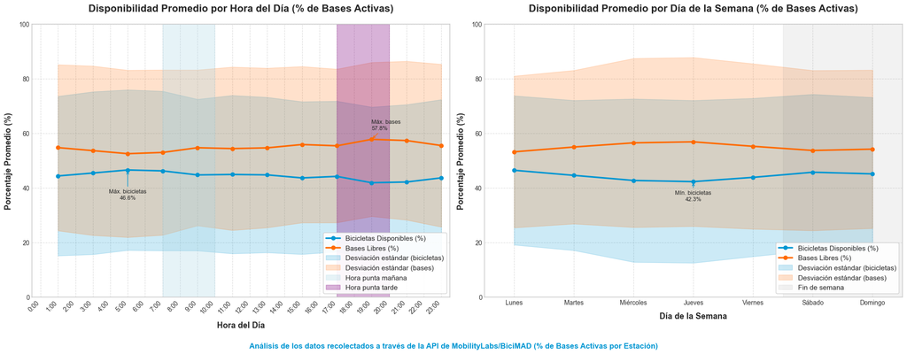

```python
# Configuración general para un estilo más profesional
plt.style.use('seaborn-v0_8-whitegrid')

# Definimos los colores corporativos de BiciMAD
bicimad_blue = '#0096d2'  # Azul BiciMAD
bicimad_orange = '#FF6B00'  # Color contrastante para las bases
morning_peak_color = '#ADD8E6'  # Azul claro para la mañana
evening_peak_color = '#800080'  # Morado para la tarde

# Configuración global de matplotlib para una mejor apariencia
mpl.rcParams['font.family'] = 'sans-serif'
mpl.rcParams['font.sans-serif'] = ['Arial', 'Helvetica', 'DejaVu Sans']
mpl.rcParams['axes.edgecolor'] = '#333333'
mpl.rcParams['axes.linewidth'] = 1.2
mpl.rcParams['xtick.color'] = '#333333'
mpl.rcParams['ytick.color'] = '#333333'

# Filtrar el DataFrame para incluir solo las estaciones activas
df_active = df[df['real_status'] == 'active'].copy()

# Extraer el día de la semana y la hora del día
df_active['timestamp'] = pd.to_datetime(df_active['timestamp'])
df_active['day_of_week_num'] = df_active['timestamp'].dt.dayofweek  # Lunes=0, Domingo=6
df_active['hour_of_day'] = df_active['timestamp'].dt.hour

# Crear un diccionario para mapear los números de día a nombres
days = {0: 'Lunes', 1: 'Martes', 2: 'Miércoles', 3: 'Jueves', 4: 'Viernes', 5: 'Sábado', 6: 'Domingo'}
df_active['day_of_week'] = df_active['day_of_week_num'].map(days)

# Calcular porcentajes en lugar de valores absolutos
df_active['bikes_percent'] = (df_active['available_bikes'] / df_active['active_bases']) * 100
df_active['bases_percent'] = (df_active['free_bases'] / df_active['active_bases']) * 100

# Normalización de datos - Usar porcentajes en lugar de valores absolutos
# Calcular la disponibilidad promedio por hora del día
hourly_availability = df_active.groupby('hour_of_day').agg({
    'bikes_percent': ['mean', 'std'],
    'bases_percent': ['mean', 'std']
}).reset_index()

# Renombrar las columnas para facilitar el acceso
hourly_availability.columns = ['hour_of_day', 'bikes_percent_mean', 'bikes_percent_std',
                              'bases_percent_mean', 'bases_percent_std']

# Calcular la disponibilidad promedio por día de la semana
daily_availability = df_active.groupby('day_of_week').agg({
    'bikes_percent': ['mean', 'std'],
    'bases_percent': ['mean', 'std']
}).reset_index()

# Renombrar las columnas
daily_availability.columns = ['day_of_week', 'bikes_percent_mean', 'bikes_percent_std',
                             'bases_percent_mean', 'bases_percent_std']

# Reordenar los días de la semana
daily_availability['day_order'] = daily_availability['day_of_week'].map({v: k for k, v in days.items()})
daily_availability = daily_availability.sort_values('day_order').reset_index(drop=True)
daily_availability = daily_availability.drop('day_order', axis=1)

# Crear los gráficos con diseño mejorado
fig, axes = plt.subplots(1, 2, figsize=(20, 8), dpi=100)
fig.patch.set_facecolor('white')  # Fondo blanco para toda la figura

# Gráfico de disponibilidad por hora del día
ax1 = axes[0]

# Añadir áreas sombreadas para mostrar la variabilidad
# Líneas principales
ax1.plot(hourly_availability['hour_of_day'], hourly_availability['bikes_percent_mean'],
         marker='o', linewidth=2.5, color=bicimad_blue, label='Bicicletas Disponibles (%)')
ax1.plot(hourly_availability['hour_of_day'], hourly_availability['bases_percent_mean'],
         marker='o', linewidth=2.5, color=bicimad_orange, label='Bases Libres (%)')

# Áreas sombreadas para la desviación estándar
ax1.fill_between(hourly_availability['hour_of_day'],
                 hourly_availability['bikes_percent_mean'] - hourly_availability['bikes_percent_std'],
                 hourly_availability['bikes_percent_mean'] + hourly_availability['bikes_percent_std'],
                 alpha=0.2, color=bicimad_blue, label='Desviación estándar (bicicletas)')

ax1.fill_between(hourly_availability['hour_of_day'],
                 hourly_availability['bases_percent_mean'] - hourly_availability['bases_percent_std'],
                 hourly_availability['bases_percent_mean'] + hourly_availability['bases_percent_std'],
                 alpha=0.2, color=bicimad_orange, label='Desviación estándar (bases)')

# Mejoras en el eje X para mostrar franjas horarias más claras
ax1.set_xticks(range(24))
ax1.set_xticklabels([f'{h}:00' for h in range(24)], rotation=45, ha='right')
ax1.set_xlim(-0.5, 23.5)  # Añadir un poco de espacio en los extremos

# Añadimos líneas verticales para marcar franjas horarias importantes
ax1.axvspan(7, 10, alpha=0.3, color=morning_peak_color, label='Hora punta mañana')
ax1.axvspan(17, 20, alpha=0.3, color=evening_peak_color, label='Hora punta tarde')

# Mejoras en etiquetas y título
ax1.set_title('Disponibilidad Promedio por Hora del Día (% de Bases Activas)', fontsize=16, fontweight='bold', pad=20)
ax1.set_xlabel('Hora del Día', fontsize=13, fontweight='bold', labelpad=10)
ax1.set_ylabel('Porcentaje Promedio (%)', fontsize=13, fontweight='bold', labelpad=10)

# Añadimos anotaciones para destacar puntos clave
peak_bikes_hour = hourly_availability['bikes_percent_mean'].idxmax()
peak_bases_hour = hourly_availability['bases_percent_mean'].idxmax()

# Modificar la anotación del máximo de bicicletas
ax1.annotate(f'Máx. bicicletas\n{hourly_availability.iloc[peak_bikes_hour]["bikes_percent_mean"]:.1f}%',
             xy=(hourly_availability.iloc[peak_bikes_hour]['hour_of_day'],
                 hourly_availability.iloc[peak_bikes_hour]['bikes_percent_mean']),
             xytext=(0, -30),  # Cambiar a valor negativo para que aparezca debajo
             textcoords='offset points',
             fontsize=9,
             va='top',  # Alineación vertical arriba
             ha='center',  # Alineación horizontal centrada
             arrowprops=dict(arrowstyle='->', color=bicimad_blue))

ax1.annotate(f'Máx. bases\n{hourly_availability.iloc[peak_bases_hour]["bases_percent_mean"]:.1f}%',
             xy=(hourly_availability.iloc[peak_bases_hour]['hour_of_day'],
                 hourly_availability.iloc[peak_bases_hour]['bases_percent_mean']),
             xytext=(0, 15), textcoords='offset points', fontsize=9,
             arrowprops=dict(arrowstyle='->', color=bicimad_orange))

# Gráfico de disponibilidad por día de la semana
ax2 = axes[1]

# Líneas principales
ax2.plot(daily_availability['day_of_week'], daily_availability['bikes_percent_mean'],
         marker='o', linewidth=2.5, color=bicimad_blue, label='Bicicletas Disponibles (%)')
ax2.plot(daily_availability['day_of_week'], daily_availability['bases_percent_mean'],
         marker='o', linewidth=2.5, color=bicimad_orange, label='Bases Libres (%)')

# Áreas sombreadas para la desviación estándar
ax2.fill_between(range(len(daily_availability)),
                 daily_availability['bikes_percent_mean'] - daily_availability['bikes_percent_std'],
                 daily_availability['bikes_percent_mean'] + daily_availability['bikes_percent_std'],
                 alpha=0.2, color=bicimad_blue, label='Desviación estándar (bicicletas)')

ax2.fill_between(range(len(daily_availability)),
                 daily_availability['bases_percent_mean'] - daily_availability['bases_percent_std'],
                 daily_availability['bases_percent_mean'] + daily_availability['bases_percent_std'],
                 alpha=0.2, color=bicimad_orange, label='Desviación estándar (bases)')

# Mejoras en el eje X
ax2.set_xticks(range(len(daily_availability)))
ax2.set_xticklabels(daily_availability['day_of_week'], rotation=0)
ax2.set_xlim(-0.5, len(daily_availability) - 0.5)

# Destacamos fin de semana
ax2.axvspan(4.5, 6.5, alpha=0.1, color='grey', label='Fin de semana')

# Mejoras en etiquetas y título
ax2.set_title('Disponibilidad Promedio por Día de la Semana (% de Bases Activas)', fontsize=16, fontweight='bold', pad=20)
ax2.set_xlabel('Día de la Semana', fontsize=13, fontweight='bold', labelpad=10)
ax2.set_ylabel('Porcentaje Promedio (%)', fontsize=13, fontweight='bold', labelpad=10)

# Añadimos anotaciones para destacar puntos clave en días
min_bikes_day_idx = daily_availability['bikes_percent_mean'].idxmin()
min_bikes_day = daily_availability.loc[min_bikes_day_idx, 'day_of_week']
min_bikes_value = daily_availability.loc[min_bikes_day_idx, 'bikes_percent_mean']

ax2.annotate(f'Mín. bicicletas\n{min_bikes_value:.1f}%',
             xy=(min_bikes_day_idx, min_bikes_value),
             xytext=(0, -30), textcoords='offset points', fontsize=9, ha='center',
             arrowprops=dict(arrowstyle='->', color=bicimad_blue))

# Mejoras comunes para ambos gráficos
for ax in [ax1, ax2]:
    # Leyenda mejorada
    legend = ax.legend(fontsize=11, loc='lower right', frameon=True)
    legend.get_frame().set_facecolor('white')
    legend.get_frame().set_alpha(0.9)
    legend.get_frame().set_edgecolor('#cccccc')

    # Cuadrícula más sutil
    ax.grid(True, linestyle='--', alpha=0.7, color='#cccccc')

    # Límites del eje Y para mejor comparación visual
    ax.set_ylim(0, 100)  # Porcentajes de 0 a 100%

    # Mejoramos el aspecto de los bordes
    for spine in ax.spines.values():
        spine.set_edgecolor('#cccccc')

# Añadimos marca de agua de BiciMAD
fig.text(0.5, 0.01, 'Análisis de los datos recolectados a través de la API de MobilityLabs/BiciMAD (% de Bases Activas por Estación)',
         fontsize=12, color=bicimad_blue, ha='center', fontweight='bold')

# Ajustamos el diseño
plt.tight_layout()
plt.subplots_adjust(top=0.9, bottom=0.15)

# Mostramos el gráfico
plt.show()
```

### **Gráfico: Patrones de Disponibilidad en el Sistema BiciMAD**

El gráfico muestra la disponibilidad porcentual promedio de bicicletas y bases libres en el sistema BiciMAD, analizando patrones por hora del día (izquierda) y por día de la semana (derecha). Los datos se presentan normalizados como porcentaje del total de bases por estación, lo que permite una comparación más precisa entre estaciones de diferentes tamaños.

Esta visualización normalizada permite identificar no solo los patrones temporales de uso, sino también cuánta variabilidad existe entre diferentes estaciones del sistema, ofreciendo una visión más completa del comportamiento de la red BiciMAD a lo largo del tiempo.

## **2.- ¿Cuales son las estaciones con mayor y menor ocupación de bases de anclaje?**

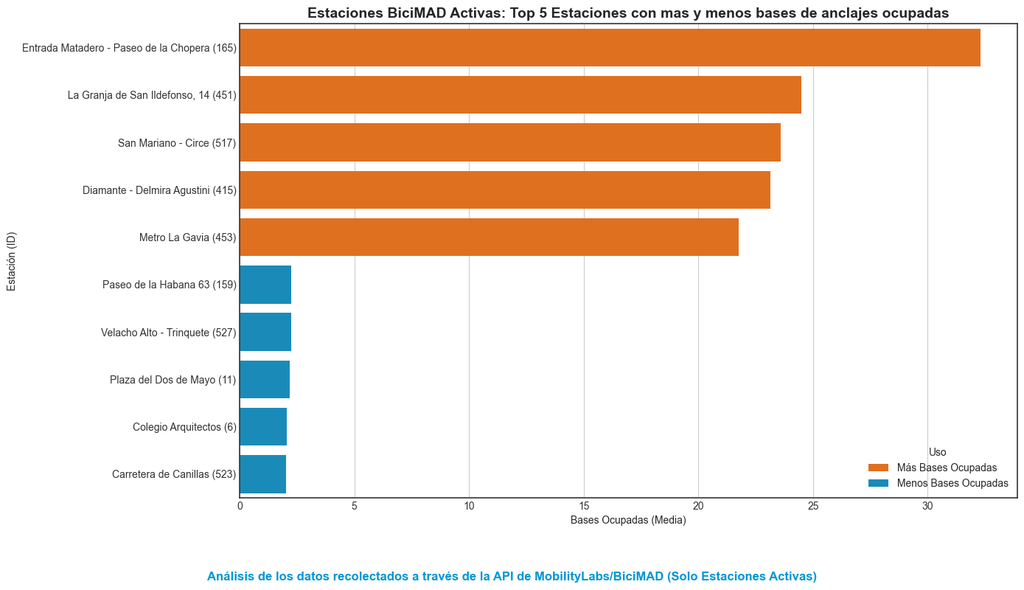

```python
# Definir los colores corporativos de BiciMAD
bicimad_blue = '#0096d2'
bicimad_orange = '#FF6B00'

# Filtrar solo las estaciones activas
active_df = df[df['real_status'] == 'active'].copy()

# Calcular capacidad total (bases totales)
active_df['active_bases'] = active_df['available_bikes'] + active_df['free_bases']

# Calcular bases ocupadas (bases totales menos bases libres)
active_df['bases_ocupadas'] = active_df['active_bases'] - active_df['free_bases']

# Agrupar y calcular medias por estación
uso_estaciones_activas = active_df.groupby(['public_station_id', 'name'])[
    ['available_bikes', 'free_bases', 'active_bases', 'bases_ocupadas']
].mean()

# Resetear el índice para poder acceder a 'public_station_id' y 'name' como columnas
uso_estaciones_activas = uso_estaciones_activas.reset_index()

# Obtener las 5 estaciones activas con más bases ocupadas
top_5_bases_ocupadas = uso_estaciones_activas.nlargest(5, 'bases_ocupadas')

# Obtener las 5 estaciones activas con menos bases ocupadas
bottom_5_bases_ocupadas = uso_estaciones_activas.nsmallest(5, 'bases_ocupadas')

# Crear DataFrames para el gráfico
top_bases_ocupadas_df = pd.DataFrame({
    'Estación': top_5_bases_ocupadas['name'] + ' (' + top_5_bases_ocupadas['public_station_id'].astype(str) + ')',
    'Bases Ocupadas': top_5_bases_ocupadas['bases_ocupadas'],
    'Tipo': 'Más Bases Ocupadas'
})

bottom_bases_ocupadas_df = pd.DataFrame({
    'Estación': bottom_5_bases_ocupadas['name'] + ' (' + bottom_5_bases_ocupadas['public_station_id'].astype(str) + ')',
    'Bases Ocupadas': bottom_5_bases_ocupadas['bases_ocupadas'],
    'Tipo': 'Menos Bases Ocupadas'
}).sort_values(by='Bases Ocupadas', ascending=False)

grafico_bases_ocupadas_df = pd.concat([top_bases_ocupadas_df, bottom_bases_ocupadas_df])

# Crear el gráfico de barras
fig, ax = plt.subplots(figsize=(14, 8), dpi=100)
sns.barplot(
    data=grafico_bases_ocupadas_df,
    y='Estación',
    x='Bases Ocupadas',
    hue='Tipo',
    orient='h',
    palette={'Más Bases Ocupadas': bicimad_orange, 'Menos Bases Ocupadas': bicimad_blue},
    ax=ax
)

plt.title("Estaciones BiciMAD Activas: Top 5 Estaciones con mas y menos bases de anclajes ocupadas", fontsize=14, fontweight='bold')
plt.xlabel('Bases Ocupadas (Media)', fontsize=10)
plt.ylabel('Estación (ID)', fontsize=10)
plt.legend(title='Uso')
plt.tight_layout(rect=[0, 0.15, 1, 1])

# Añadimos marca de agua de BiciMAD
fig.text(0.5, 0.01, 'Análisis de los datos recolectados a través de la API de MobilityLabs/BiciMAD (Solo Estaciones Activas)',
         fontsize=12, color=bicimad_blue, ha='center', fontweight='bold')

plt.subplots_adjust(bottom=0.15)
plt.show()
```

### **Gráfico: Estaciones BiciMAD Activas: Top 5 Estaciones con más y menos bases de anclajes ocupadas.**

El gráfico compara las 5 estaciones BiciMAD con mayor y menor número de bases de anclaje ocupadas en promedio. Las barras naranjas representan las estaciones con más bases ocupadas, encabezadas por **"Entrada Matadero - Paseo de la Chopera (165)"** con aproximadamente 30 bases ocupadas de media. Le siguen **"La Granja de San Ildefonso, 14 (451)"**, **"San Mariano - Circa (517)"**, **"Diamante - Delmira Agustini (415)"** y **"Metro La Gavia (453)"**. Las barras azules muestran las estaciones con menos bases ocupadas, todas con valores cercanos a 2 bases ocupadas de media, incluyendo **"Carretera de Canillas (523)"**, **"Colegio Arquitectos (6)"**, **"Plaza del Dos de Mayo (11)"**, **"Velacho Alto - Trinquete (527)"** y **"Paseo de la Habana 63 (159)"**.

Este análisis permite identificar patrones de uso y posibles necesidades de rebalanceo en el sistema BiciMAD.

## **3.-¿Cómo se distribuyen las bicicletas y las bases libres en las estaciones?**

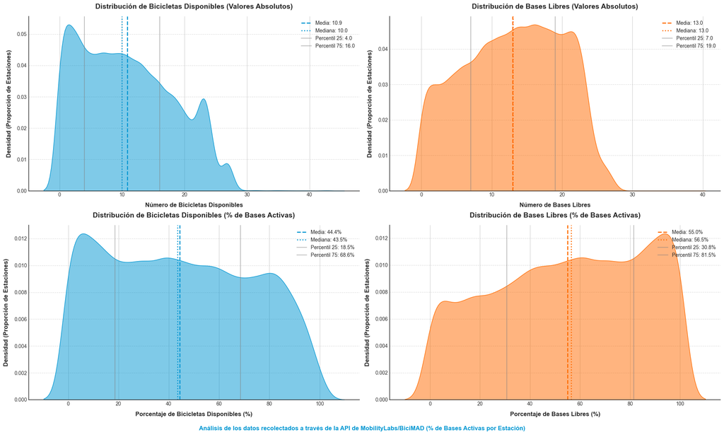

```python
# Seguimos usando df_active ya que tomaremos en cuenta solo las bases activas

# Configuración general para un estilo más profesional
plt.style.use('seaborn-v0_8-whitegrid')

# Definir los colores corporativos de BiciMAD
bicimad_blue = '#0096d2'
bicimad_orange = '#FF6B00'
palette = [bicimad_blue, '#5bc0de', '#8fddff']  # Paleta de colores para los grupos

# Configuración global de matplotlib para una mejor apariencia
mpl.rcParams['font.family'] = 'sans-serif'
mpl.rcParams['font.sans-serif'] = ['Arial', 'Helvetica', 'DejaVu Sans']
mpl.rcParams['axes.edgecolor'] = '#333333'
mpl.rcParams['axes.linewidth'] = 1.2
mpl.rcParams['xtick.color'] = '#333333'
mpl.rcParams['ytick.color'] = '#333333'

# Usaremos df_active ya que solo tomaremos en cuenta las estaciones activas

# Normalización - Calcular el porcentaje de bicicletas y bases libres
df_active['bikes_percent'] = (df_active['available_bikes'] / df_active['active_bases']) * 100
df_active['bases_percent'] = (df_active['free_bases'] / df_active['active_bases']) * 100

fig, axes = plt.subplots(2, 2, figsize=(20, 12), dpi=100)
fig.patch.set_facecolor('white')  # Fondo blanco para toda la figura

# Fila superior: Valores absolutos

# Diagrama de densidad de la distribución de bicicletas disponibles
sns.kdeplot(df_active['available_bikes'], color=bicimad_blue, fill=True, alpha=0.5, ax=axes[0, 0])
axes[0, 0].set_title('Distribución de Bicicletas Disponibles (Valores Absolutos)', fontsize=14, fontweight='bold', pad=15)
axes[0, 0].set_xlabel('Número de Bicicletas Disponibles', fontsize=12, fontweight='bold', labelpad=10)
axes[0, 0].set_ylabel('Densidad (Proporción de Estaciones)', fontsize=12, fontweight='bold', labelpad=10)
axes[0, 0].grid(axis='y', linestyle='--', alpha=0.7, color='#cccccc')
axes[0, 0].spines['top'].set_visible(False)
axes[0, 0].spines['right'].set_visible(False)
axes[0, 0].tick_params(axis='both', which='major', labelsize=10)

# Estadísticas descriptivas - Añadir líneas para media y mediana (bicicletas)
bikes_mean = df_active['available_bikes'].mean()
bikes_median = df_active['available_bikes'].median()
axes[0, 0].axvline(bikes_mean, color=bicimad_blue, linestyle='--', linewidth=2,
                 label=f'Media: {bikes_mean:.1f}')
axes[0, 0].axvline(bikes_median, color=bicimad_blue, linestyle=':', linewidth=2,
                 label=f'Mediana: {bikes_median:.1f}')

# Anotaciones - Añadir percentiles importantes (bicicletas)
bikes_p25 = df_active['available_bikes'].quantile(0.25)
bikes_p75 = df_active['available_bikes'].quantile(0.75)
axes[0, 0].axvline(bikes_p25, color='gray', linestyle='-', alpha=0.5, linewidth=1.5,
                 label=f'Percentil 25: {bikes_p25:.1f}')
axes[0, 0].axvline(bikes_p75, color='gray', linestyle='-', alpha=0.5, linewidth=1.5,
                 label=f'Percentil 75: {bikes_p75:.1f}')
axes[0, 0].legend(loc='upper right', fontsize=10)

# Diagrama de densidad de la distribución de bases libres
sns.kdeplot(df_active['free_bases'], color=bicimad_orange, fill=True, alpha=0.5, ax=axes[0, 1])
axes[0, 1].set_title('Distribución de Bases Libres (Valores Absolutos)', fontsize=14, fontweight='bold', pad=15)
axes[0, 1].set_xlabel('Número de Bases Libres', fontsize=12, fontweight='bold', labelpad=10)
axes[0, 1].set_ylabel('Densidad (Proporción de Estaciones)', fontsize=12, fontweight='bold', labelpad=10)
axes[0, 1].grid(axis='y', linestyle='--', alpha=0.7, color='#cccccc')
axes[0, 1].spines['top'].set_visible(False)
axes[0, 1].spines['right'].set_visible(False)
axes[0, 1].tick_params(axis='both', which='major', labelsize=10)

# Estadísticas descriptivas - Añadir líneas para media y mediana (bases)
bases_mean = df_active['free_bases'].mean()
bases_median = df_active['free_bases'].median()
axes[0, 1].axvline(bases_mean, color=bicimad_orange, linestyle='--', linewidth=2,
                 label=f'Media: {bases_mean:.1f}')
axes[0, 1].axvline(bases_median, color=bicimad_orange, linestyle=':', linewidth=2,
                 label=f'Mediana: {bases_median:.1f}')

# Anotaciones - Añadir percentiles importantes (bases)
bases_p25 = df_active['free_bases'].quantile(0.25)
bases_p75 = df_active['free_bases'].quantile(0.75)
axes[0, 1].axvline(bases_p25, color='gray', linestyle='-', alpha=0.5, linewidth=1.5,
                 label=f'Percentil 25: {bases_p25:.1f}')
axes[0, 1].axvline(bases_p75, color='gray', linestyle='-', alpha=0.5, linewidth=1.5,
                 label=f'Percentil 75: {bases_p75:.1f}')
axes[0, 1].legend(loc='upper right', fontsize=10)

# Fila inferior: Valores normalizados (porcentajes)

# Normalización - Mostrar distribuciones normalizadas
sns.kdeplot(df_active['bikes_percent'], color=bicimad_blue, fill=True, alpha=0.5, ax=axes[1, 0])
axes[1, 0].set_title('Distribución de Bicicletas Disponibles (% de Bases Activas)', fontsize=14, fontweight='bold', pad=15)
axes[1, 0].set_xlabel('Porcentaje de Bicicletas Disponibles (%)', fontsize=12, fontweight='bold', labelpad=10)
axes[1, 0].set_ylabel('Densidad (Proporción de Estaciones)', fontsize=12, fontweight='bold', labelpad=10)
axes[1, 0].grid(axis='y', linestyle='--', alpha=0.7, color='#cccccc')
axes[1, 0].spines['top'].set_visible(False)
axes[1, 0].spines['right'].set_visible(False)
axes[1, 0].tick_params(axis='both', which='major', labelsize=10)

# Estadísticas descriptivas para porcentajes de bicicletas
bikes_pct_mean = df_active['bikes_percent'].mean()
bikes_pct_median = df_active['bikes_percent'].median()
axes[1, 0].axvline(bikes_pct_mean, color=bicimad_blue, linestyle='--', linewidth=2,
                 label=f'Media: {bikes_pct_mean:.1f}%')
axes[1, 0].axvline(bikes_pct_median, color=bicimad_blue, linestyle=':', linewidth=2,
                 label=f'Mediana: {bikes_pct_median:.1f}%')

# Percentiles para porcentajes de bicicletas
bikes_pct_p25 = df_active['bikes_percent'].quantile(0.25)
bikes_pct_p75 = df_active['bikes_percent'].quantile(0.75)
axes[1, 0].axvline(bikes_pct_p25, color='gray', linestyle='-', alpha=0.5, linewidth=1.5,
                 label=f'Percentil 25: {bikes_pct_p25:.1f}%')
axes[1, 0].axvline(bikes_pct_p75, color='gray', linestyle='-', alpha=0.5, linewidth=1.5,
                 label=f'Percentil 75: {bikes_pct_p75:.1f}%')
axes[1, 0].legend(loc='upper right', fontsize=10)

# Distribución de bases libres (porcentaje)
sns.kdeplot(df_active['bases_percent'], color=bicimad_orange, fill=True, alpha=0.5, ax=axes[1, 1])
axes[1, 1].set_title('Distribución de Bases Libres (% de Bases Activas)', fontsize=14, fontweight='bold', pad=15)
axes[1, 1].set_xlabel('Porcentaje de Bases Libres (%)', fontsize=12, fontweight='bold', labelpad=10)
axes[1, 1].set_ylabel('Densidad (Proporción de Estaciones)', fontsize=12, fontweight='bold', labelpad=10)
axes[1, 1].grid(axis='y', linestyle='--', alpha=0.7, color='#cccccc')
axes[1, 1].spines['top'].set_visible(False)
axes[1, 1].spines['right'].set_visible(False)
axes[1, 1].tick_params(axis='both', which='major', labelsize=10)

# Estadísticas descriptivas para porcentajes de bases
bases_pct_mean = df_active['bases_percent'].mean()
bases_pct_median = df_active['bases_percent'].median()
axes[1, 1].axvline(bases_pct_mean, color=bicimad_orange, linestyle='--', linewidth=2,
                 label=f'Media: {bases_pct_mean:.1f}%')
axes[1, 1].axvline(bases_pct_median, color=bicimad_orange, linestyle=':', linewidth=2,
                 label=f'Mediana: {bases_pct_median:.1f}%')

# Percentiles para porcentajes de bases
bases_pct_p25 = df_active['bases_percent'].quantile(0.25)
bases_pct_p75 = df_active['bases_percent'].quantile(0.75)
axes[1, 1].axvline(bases_pct_p25, color='gray', linestyle='-', alpha=0.5, linewidth=1.5,
                 label=f'Percentil 25: {bases_pct_p25:.1f}%')
axes[1, 1].axvline(bases_pct_p75, color='gray', linestyle='-', alpha=0.5, linewidth=1.5,
                 label=f'Percentil 75: {bases_pct_p75:.1f}%')
axes[1, 1].legend(loc='upper right', fontsize=10)

plt.tight_layout()

# Añadimos marca de agua de BiciMAD
fig.text(0.5, 0.01, 'Análisis de los datos recolectados a través de la API de MobilityLabs/BiciMAD (% de Bases Activas por Estación)', fontsize=12,
         color=bicimad_blue, ha='center', fontweight='bold')

plt.subplots_adjust(bottom=0.08)

plt.show()
```

### **Gráfico: Análisis de la Distribución de Bicicletas y Bases en el Sistema BiciMAD**

Este gráfico presenta un análisis detallado de la distribución de bicicletas disponibles y bases libres en el sistema BiciMAD de Madrid, considerando únicamente las estaciones activas. El análisis se presenta tanto en valores absolutos como en porcentajes normalizados del total de bases por estación.

#### **Distribución Normalizada (Fila Inferior)**

Esta visualización permite identificar no solo la disponibilidad absoluta de recursos en el sistema BiciMAD, sino también su distribución relativa, facilitando la detección de posibles desequilibrios en la red y oportunidades para optimizar la redistribución de bicicletas entre estaciones.

## **4.- ¿Existe una relación entre el tamaño de una estación (su capacidad total de bases) y la demanda o el uso que experimenta?**

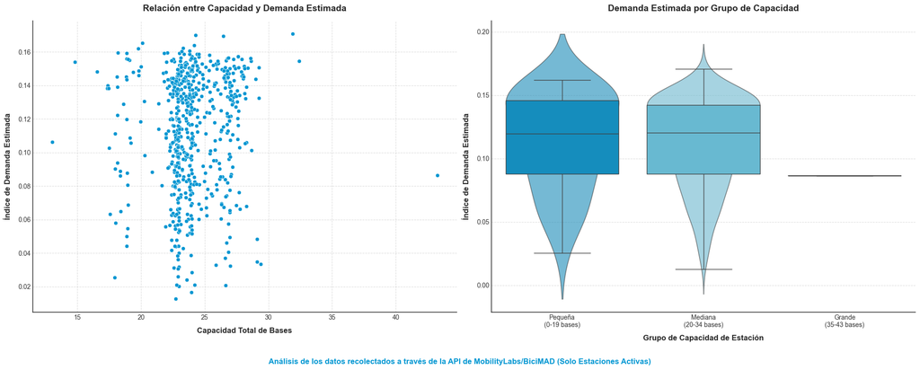

```python
# Configuración general para un estilo más profesional
plt.style.use('seaborn-v0_8-whitegrid')

# Definir los colores corporativos de BiciMAD
bicimad_blue = '#0096d2'
bicimad_orange = '#FF6B00'
palette = [bicimad_blue, '#5bc0de', '#8fddff']  # Paleta de colores para los grupos

# Configuración global de matplotlib para una mejor apariencia
mpl.rcParams['font.family'] = 'sans-serif'
mpl.rcParams['font.sans-serif'] = ['Arial', 'Helvetica', 'DejaVu Sans']
mpl.rcParams['axes.edgecolor'] = '#333333'
mpl.rcParams['axes.linewidth'] = 1.2
mpl.rcParams['xtick.color'] = '#333333'
mpl.rcParams['ytick.color'] = '#333333'

#Vamos a usar una medida que nos entregue los resultado de Balance * Volatilidad para calcular la demanda promedio de todas las estaciones

# Filtrar solo estaciones activas


# Calcular índice de balance
df_active['balance'] = 1 - abs((df_active['available_bikes'] / df_active['active_bases']) - 0.5) * 2

# Calcular demanda
if 'timestamp' in df_active.columns:
    df_active['fecha_hora'] = pd.to_datetime(df_active['timestamp']).dt.floor('h')
    volatilidad = df_active.groupby('name')['available_bikes'].std()
    # Calcular la demanda promedio por estación
    demanda_estimada = df_active.groupby('name')['balance'].mean() * volatilidad
    # Normalizar la demanda estimada
    demanda_estimada = demanda_estimada / df_active.groupby('name')['active_bases'].mean()
else:
    demanda_estimada = df_active.groupby('name')['balance'].mean()

# Crear un DataFrame con la capacidad de cada estación y su demanda estimada
station_capacity_demanda = df_active.groupby('name')['active_bases'].mean().reset_index()
station_capacity_demanda['demanda_estimada'] = demanda_estimada.reset_index(name='demanda_estimada')['demanda_estimada']

# Definir los rangos de capacidad (ajusta estos umbrales según tus datos reales)
bins = [0, 20, 35, station_capacity_demanda['active_bases'].max() + 1]
labels = ['Pequeña', 'Mediana', 'Grande']
station_capacity_demanda['capacity_group'] = pd.cut(station_capacity_demanda['active_bases'], bins=bins, labels=labels, right=False)

# Creamos un diccionario de rangos directamente de los bins
range_dict = {
    'Pequeña': f"({bins[0]}-{bins[1]-1} bases)",
    'Mediana': f"({bins[1]}-{bins[2]-1} bases)",
    'Grande': f"({bins[2]}-{int(station_capacity_demanda['active_bases'].max())} bases)"
}

#Creamos los gráficos
fig, axes = plt.subplots(1, 2, figsize=(20, 8), dpi=100)
fig.patch.set_facecolor('white')

# Gráfico de dispersión (Relación entre capacidad y demanda estimada)
sns.scatterplot(x='active_bases', y='demanda_estimada', data=station_capacity_demanda, color=bicimad_blue, ax=axes[0])
axes[0].set_title('Relación entre Capacidad y Demanda Estimada', fontsize=14, fontweight='bold', pad=15)
axes[0].set_xlabel('Capacidad Total de Bases', fontsize=12, fontweight='bold', labelpad=10)
axes[0].set_ylabel('Índice de Demanda Estimada', fontsize=12, fontweight='bold', labelpad=10)
axes[0].grid(True, linestyle='--', alpha=0.7, color='#cccccc')
axes[0].spines['top'].set_visible(False)
axes[0].spines['right'].set_visible(False)
axes[0].tick_params(axis='both', which='major', labelsize=10)

# Gráfico de violin + boxplot combinado (Demanda estimada por grupo de capacidad)
sns.violinplot(x='capacity_group', y='demanda_estimada', data=station_capacity_demanda, hue='capacity_group', palette=palette, inner=None, alpha=0.6, ax=axes[1], legend=False)
sns.boxplot(x='capacity_group', y='demanda_estimada', data=station_capacity_demanda, hue='capacity_group', palette=palette, saturation=0.8, showfliers=True, ax=axes[1], legend=False)
axes[1].set_title('Demanda Estimada por Grupo de Capacidad', fontsize=14, fontweight='bold', pad=15)
axes[1].set_xlabel('Grupo de Capacidad de Estación', fontsize=12, fontweight='bold', labelpad=10)
axes[1].set_ylabel('Índice de Demanda Estimada', fontsize=12, fontweight='bold', labelpad=10)
axes[1].grid(axis='y', linestyle='--', alpha=0.7, color='#cccccc')
axes[1].spines['top'].set_visible(False)
axes[1].spines['right'].set_visible(False)
axes[1].tick_params(axis='both', which='major', labelsize=10)

# Definimos las etiquetas personalizadas para el eje X
custom_labels = [f'Pequeña\n{range_dict.get("Pequeña", "")}',
                 f'Mediana\n{range_dict.get("Mediana", "")}',
                 f'Grande\n{range_dict.get("Grande", "")}']

# Establecemos las etiquetas personalizadas en el eje X
axes[1].set_xticks([0, 1, 2])  # Asegurarse de que los ticks estén en las posiciones correctas
axes[1].set_xticklabels(custom_labels)

plt.tight_layout()

# Añadimos marca de agua de BiciMAD
fig.text(0.5, 0.01, 'Análisis de los datos recolectados a través de la API de MobilityLabs/BiciMAD (Solo Estaciones Activas)', fontsize=12,
          color=bicimad_blue, ha='center', fontweight='bold')

plt.subplots_adjust(bottom=0.15)  # Ajustar un poco más el espacio inferior

plt.show()
```